# Loading Cell Boundaries

D. Ford Hannum

2023-05-23

# Cell Segmentation

Here we will demonstrate how to read in a parquet file containing the cell segmentation results from Vizgen. For this walk through in R we will use the [sfarrow package](https://github.com/wcjochem/sfarrow) to read in the parquet, and the [sf](https://r-spatial.github.io/sf/) to view the segmentations.

The data consists of polygons for cell boundaries across seven z-planes (note not all cells are found in every z-plane).

## Overview

- Cell boundaries are stored in a single file called cell_boundaries.parquet
- This file format is an open-source tabular format with excellent I/O performance
- Cell boundaries are in the units of microns
- This data is generated using GeoPandas
- This file format supplants the hdf5 files used in prior versions of the MERSCOPE Instrument Software

## Column Information:

- `[BLANK]` The first, unnamed column is a numeric index. It is sorted and unique, but entries are not consecutive.
- `ID` is a numeric row index that begins from zero. `ID` is unique within an analysis region.
- `EntityID` is an integer (int64) identifier for a cell or other biological entity identified through spatial analysis. `EntityID` has the format: analysis time stamp (%m%d%H%M%S), task index, tile index, geometry index. `EntityID` is guaranteed to be unique to a biological entity (cell) within an analysis region. The use of the analysis time stamp in the ID makes the `EntityID` likely to be unique across all experiments run on an instrument.
- `Name` A free-text description of the geometry in the row.
- `Type` The type of the entity referred to in `EntityID`.
- `ZIndex` The z-index of this slice of the biological entity in the 3D stack, corresponds to `global_z` in `detected_transcripts.csv`.
- `ZLevel` The z-position of this slice of the biological entity in the 3D stack, expressed in units of microns.
- `Geometry` A valid WKT-format MultiPolygon that describes the biological entity (cell) at the given z-level. The vertices of the MultiPolygon are in units of microns relative to the space of the experimental region. `Geometry` uses MultiPolygon objects in order to describe biological entities that may be contiguous in 3D space, but dis-contiguous at a given z-level (i.e. a U-shaped cell). Even if the cell region is contiguous and can be described with a single Polygon, it is stored as a MultiPolygon for data-type consistency.
- `ParentID` If this biological entity is related to a higher-level (“parent”) entity, the `EntityID` of the parent may be stored here. For example, a “cell” entity may be the parent of one or more “nucleus” entities. If this biological entity does not descend from a parent entity, this value is `None`.
- `ParentType` The type of the parent entity, if any. If there is no parent entity, the value is `None`.

# Code

Here we will load the packages sfarrow and sf.

```r
knitr::opts_chunk$set(echo = TRUE)
library(sfarrow)
library(sf)
# Reading in the parquet file
segmentations <- sfarrow::st_read_parquet('../data/mouse_brain_showcase/Slice-1_Replicate-1/cell_boundaries.parquet')
```

```
## The tzdb package is not installed. Timezones will not be available to Arrow compute functions.
```

```r
# Looking at the first five rows
head(segmentations,5)
```

```
## Simple feature collection with 5 features and 9 fields
## Geometry type: MULTIPOLYGON
## Dimension:     XY
## Bounding box:  xmin: 7653.865 ymin: 3591.773 xmax: 7667.819 ymax: 3608.103
## CRS:           NA
##   ID           EntityID ZIndex ZLevel Type Name ParentID ParentType
## 1  0 121919181900000000      0    1.5 cell   NA       NA         NA
## 2  1 121919181900000000      1    3.0 cell   NA       NA         NA
## 3  2 121919181900000000      2    4.5 cell   NA       NA         NA
## 4  3 121919181900000000      3    6.0 cell   NA       NA         NA
## 5  4 121919181900000000      4    7.5 cell   NA       NA         NA
##   X__index_level_0__                       Geometry
## 1                  0 MULTIPOLYGON (((7664.039 36...
## 2                  1 MULTIPOLYGON (((7664.147 36...
## 3                  2 MULTIPOLYGON (((7664.687 36...
## 4                  3 MULTIPOLYGON (((7667.819 36...
## 5                  4 MULTIPOLYGON (((7664.147 36...
```

We see that the first five polygons all refer to the same cell (EntityID) but on different z-planes (ZIndex or ZLevel).

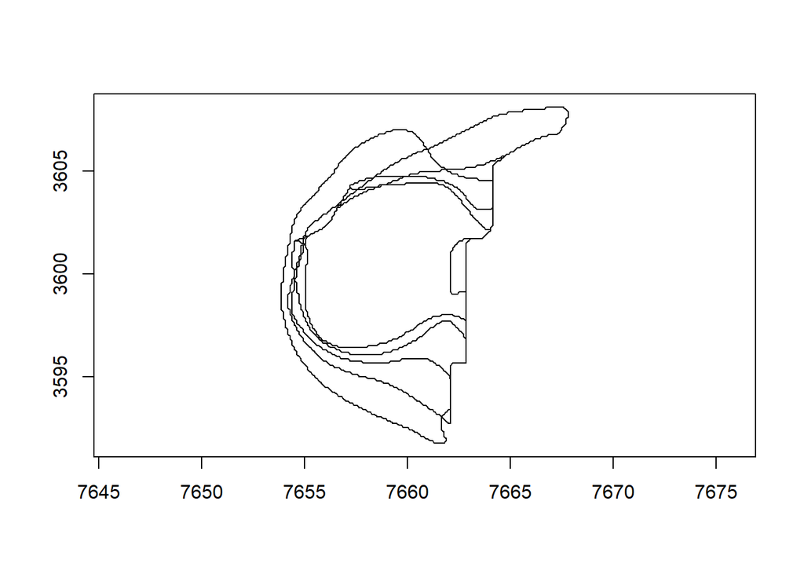

```r
# Plotting the boundaries of the first five polygons
plot(st_geometry(segmentations[1:5,]), border = 'black', axes = TRUE)
```

Now, let us look at the first five polygons that are on Z-plane = 3

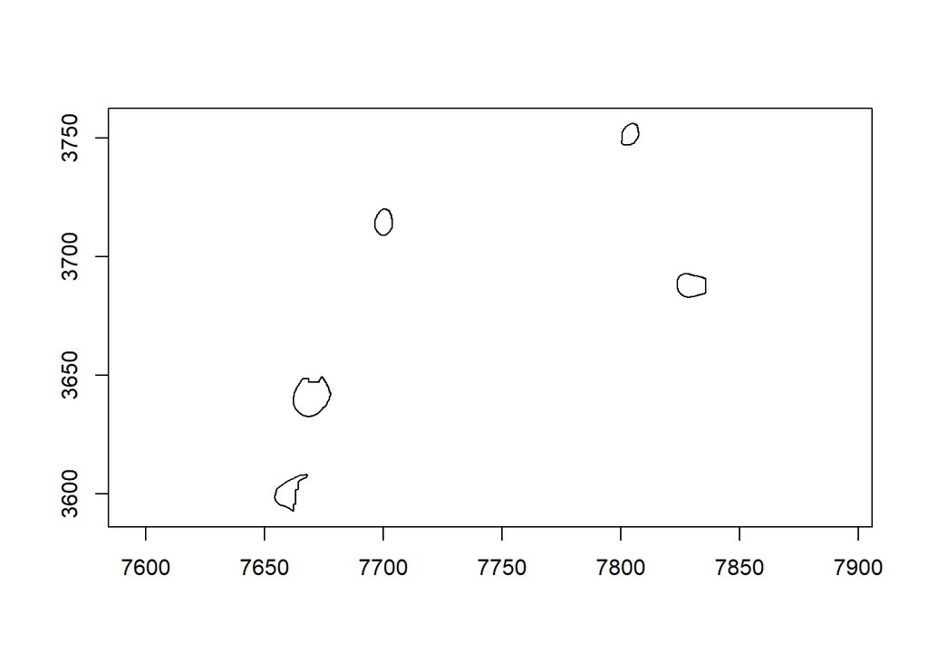

```r
# Subsetting the data to just z = 3 layer
z3 = segmentations[segmentations$ZIndex == 3,]

# Plotting the boundaries of the first five cells on z = 3
plot(st_geometry(z3[1:5,]), border = 'black', axes = TRUE)
```

Here we see are looking at five different cells.

It will take longer to run but we can look at all the cells that pass through Z-plane = 3.

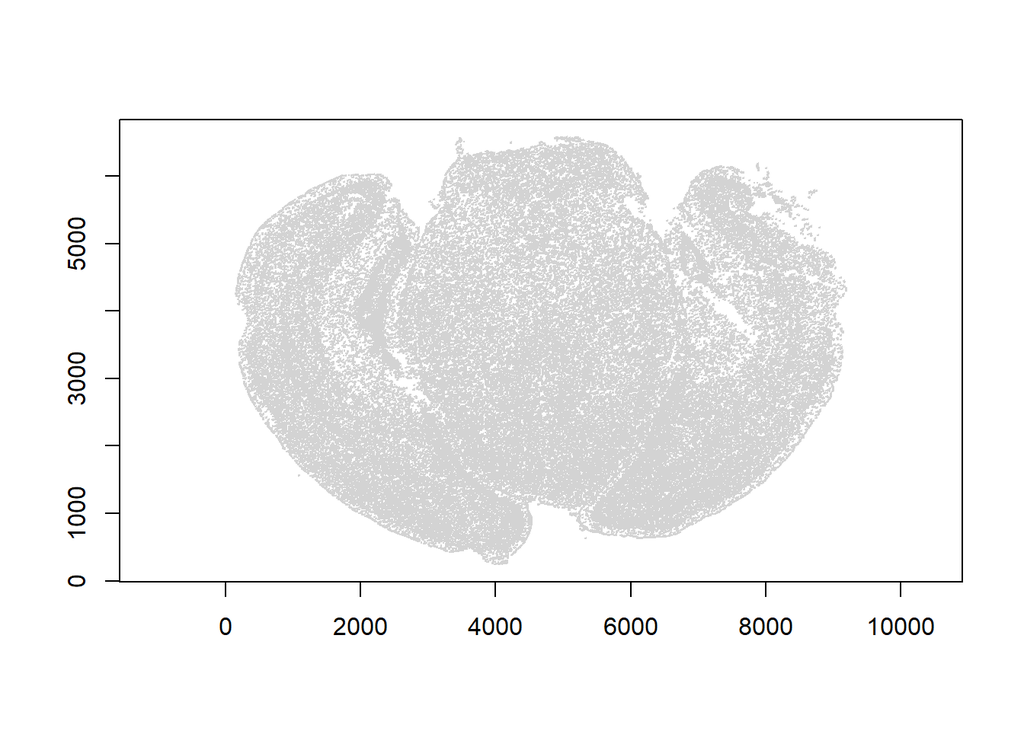

```r
# Plotting all cell boundaries on z = 3
plot(st_geometry(z3), border='lightgrey', axes = TRUE)
```